# Detecting Weak Tones in the FFT

### Windowing and Coherent vs Non‑Coherent Sampling (Python Tutorial)

## Objective

We want to detect a **weak sinusoid** hidden next to a **strong sinusoid** using an **N‑point FFT**.

We’ll see how detection depends on:

- **Window**: Rectangular vs Blackman–Harris
- **Sampling**: coherent (tone exactly on an FFT bin) vs non‑coherent (tone slightly off-bin)
- **Weak tone level**: −40 dB (`a2=0.01`) and −60 dB (`a2=0.001`)
- **Separation** in FFT bins: `p` (how many bins apart the tones are)

> The examples are inspired by standard signal‑processing practice in communication systems.  
> All code and explanations here are original and intended for educational use.

```python
import numpy as np
import matplotlib.pyplot as plt
from scipy.signal.windows import blackmanharris

plt.rcParams["figure.figsize"] = (10, 4)
plt.rcParams["axes.grid"] = True

# Lab-style parameters
N = 8192
n = np.arange(N)

# Two windows to compare
w_rect = np.ones(N)
w_bh   = blackmanharris(N)

def db(x):
    x = np.maximum(np.abs(x), 1e-300)
    return 20*np.log10(x)

def fft_db_normalized(x, w):
    """Window + FFT + magnitude in dB, normalized so max is 0 dB."""
    X = np.fft.fft(x * w)
    A = db(X) - np.max(db(X))
    return A, X
```

## 1) Signal model

We use a two-tone discrete-time signal

$$ x[n] = \sin(\omega_1 n) + a_2 \sin(\omega_2 n), \qquad n=0,\dots,N-1 $$

- The first tone has amplitude **1** (the “strong” tone).
- The second tone has amplitude **$a_2$** (the “weak” tone):
  - $a_2=0.01$ (≈ −40 dB)
  - $a_2=0.001$ (≈ −60 dB)

The tone spacing is controlled by an integer **bin offset** $p$:

$$ \omega_2 = \omega_1 + \Delta\omega,\qquad \Delta\omega = \frac{2\pi p}{N} $$

So **$p$ literally means “p FFT bins apart.”**

```python
def make_signal(N, omega1, p, a2):
    n = np.arange(N)
    domega = 2*np.pi*p/N
    omega2 = omega1 + domega
    x = np.sin(omega1*n) + a2*np.sin(omega2*n)
    return x, omega2

def omega_to_bin(omega, N):
    # omega = 2*pi*k/N  =>  k = omega*N/(2*pi)
    return omega * N / (2*np.pi)
```

## 2) Coherent vs non‑coherent sampling

We test two cases for the strong tone frequency:

- **Coherent (on‑bin):**
  $$\omega_1 = 0.25\pi$$
  This lands exactly on an FFT bin.
- **Non‑coherent (off‑bin):**
  $$\omega_1 = (0.25 + 1/N)\pi$$
  This is slightly “between bins”, causing more spectral leakage.

We’ll keep $N=8192$ fixed.

```python
omega1_coherent = 0.25*np.pi
omega1_noncoh  = (0.25 + 1/N)*np.pi

k1_coh  = omega_to_bin(omega1_coherent, N)
k1_non  = omega_to_bin(omega1_noncoh, N)

k1_coh, k1_non
```

```
(1024.0, 1024.5)
```

## 3) Detection criterion

We compute the windowed FFT and normalize the magnitude spectrum so its **maximum is 0 dB**:

$$ A[k] = 20\log_{10}\left(\frac{|X[k]|}{\max_k |X[k]|}\right) $$

The weak tone is expected at a level of:

$$ 20\log_{10}(a_2) $$

because we normalize by the strongest spectral peak (the strong tone).

**We say the weak tone is detectable** when the measured weak-tone peak is within **±0.5 dB** of that theoretical level.

```python
def measure_weak_level(A_db, k2_expected, search_radius=3):
    """Return the peak level (dB) near the expected weak-tone bin."""
    k2_round = int(np.round(k2_expected))
    lo = max(0, k2_round - search_radius)
    hi = min(len(A_db)//2, k2_round + search_radius + 1)  # use only [0, N/2)
    return np.max(A_db[lo:hi])

def detect_min_p(omega1, a2, w, p_max=200, tol_db=0.5):
    target_db = 20*np.log10(a2)
    for p in range(1, p_max+1):
        x, omega2 = make_signal(N, omega1, p, a2)
        A_db, _ = fft_db_normalized(x, w)
        k2 = omega_to_bin(omega2, N)
        weak_db = measure_weak_level(A_db, k2)
        if abs(weak_db - target_db) <= tol_db:
            return p, weak_db
    return None, None
```

## 4) Main experiment (sweep p)

For each configuration:

- window ∈ {Rectangular, Blackman–Harris}
- sampling ∈ {coherent, non‑coherent}
- weak level a2 ∈ {0.01, 0.001}

we find the **minimum p** that meets the ±0.5 dB detection rule.

```python
configs = [
    ("Rect", w_rect),
    ("Blackman–Harris", w_bh),
]

omegas = [
    ("Coherent", omega1_coherent),
    ("Non‑coherent", omega1_noncoh),
]

a2_list = [1e-2, 1e-3]

results = []
for wname, w in configs:
    for oname, omega1 in omegas:
        for a2 in a2_list:
            pmin, meas = detect_min_p(omega1, a2, w, p_max=400, tol_db=0.5)
            results.append((wname, oname, a2, pmin, meas))

results
```

```
[('Rect', 'Coherent', 0.01, 4, np.float64(-39.99999999999114)),
 ('Rect', 'Coherent', 0.001, 4, np.float64(-59.99999999991139)),
 ('Rect', 'Non‑coherent', 0.01, None, None),
 ('Rect', 'Non‑coherent', 0.001, None, None),
 ('Blackman–Harris', 'Coherent', 0.01, 7, np.float64(-39.999928338358316)),
 ('Blackman–Harris', 'Coherent', 0.001, 7, np.float64(-59.99928333924238)),
 ('Blackman–Harris', 'Non‑coherent', 0.01, 7, np.float64(-39.9785691982386)),
 ('Blackman–Harris', 'Non‑coherent', 0.001, 7, np.float64(-59.78801751738892))]
```

```python
# Pretty print
for wname, oname, a2, pmin, meas in results:
    if meas is None:
        print(f"{wname:16s} | {oname:12s} | a2={a2:g} | p_min=not found")
    else:
        print(
            f"{wname:16s} | {oname:12s} | a2={a2:g} | "
            f"p_min={pmin} | measured={meas:.2f} dB "
            f"(target {20*np.log10(a2):.2f} dB)"
        )
```

```
Rect             | Coherent     | a2=0.01 | p_min=4 | measured=-40.00 dB (target -40.00 dB)
Rect             | Coherent     | a2=0.001 | p_min=4 | measured=-60.00 dB (target -60.00 dB)
Rect             | Non‑coherent | a2=0.01 | p_min=not found
Rect             | Non‑coherent | a2=0.001 | p_min=not found
Blackman–Harris  | Coherent     | a2=0.01 | p_min=7 | measured=-40.00 dB (target -40.00 dB)
Blackman–Harris  | Coherent     | a2=0.001 | p_min=7 | measured=-60.00 dB (target -60.00 dB)
Blackman–Harris  | Non‑coherent | a2=0.01 | p_min=7 | measured=-39.98 dB (target -40.00 dB)
Blackman–Harris  | Non‑coherent | a2=0.001 | p_min=7 | measured=-59.79 dB (target -60.00 dB)
```

## 5) Visualizing the spectrum for a chosen p

Below you can pick a configuration and plot the normalized spectrum. You should see how:

- rectangular + non‑coherent sampling spreads energy (leakage),
- Blackman–Harris reduces sidelobes (cleaner floor) but has a wider mainlobe.

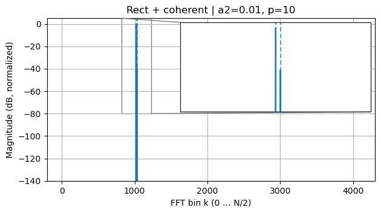

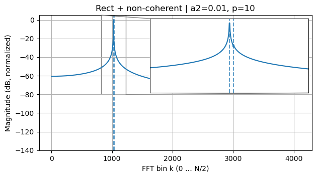

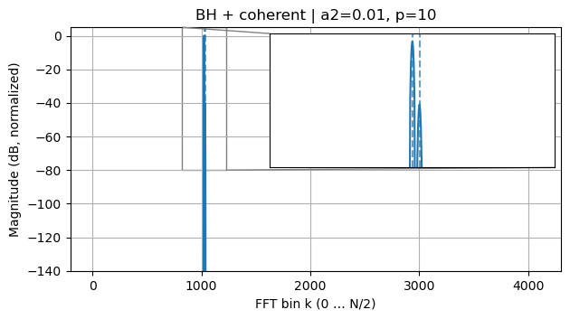

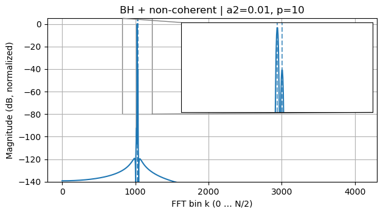

```python
from mpl_toolkits.axes_grid1.inset_locator import inset_axes, mark_inset
def plot_full_with_inset_zoom(N, omega1, a2, p, w, title, span=200):
    # --- Signal & spectrum ---
    x, omega2 = make_signal(N, omega1, p, a2)
    A_db, _ = fft_db_normalized(x, w)

    k1 = int(round(omega_to_bin(omega1, N)))
    k2 = int(round(omega_to_bin(omega2, N)))

    x1 = max(0, k1 - span)
    x2 = min(N//2, k1 + span)

    # --- Figure ---
    fig, ax = plt.subplots(figsize=(7, 3.5))

    # MAIN spectrum
    ax.plot(A_db[:N//2])
    ax.axvline(k1, linestyle="--", alpha=0.7)
    ax.axvline(k2, linestyle="--", alpha=0.7)
    ax.set_ylim(-140, 5)
    ax.set_xlabel("FFT bin k (0 … N/2)")
    ax.set_ylabel("Magnitude (dB, normalized)")
    ax.set_title(f"{title} | a2={a2:g}, p={p}")

    # INSET zoom
    axins = inset_axes(ax, width="58%", height="55%", loc="upper right")
    axins.plot(np.arange(x1, x2), A_db[x1:x2])
    axins.axvline(k1, linestyle="--", alpha=0.7)
    axins.axvline(k2, linestyle="--", alpha=0.7)
    axins.set_xlim(x1, x2)
    axins.set_ylim(-80, 5)
    axins.set_xticks([])
    axins.set_yticks([])

    mark_inset(ax, axins, loc1=2, loc2=4, fc="none", ec="0.5")
    plt.show()

plot_full_with_inset_zoom(N, omega1_coherent, 1e-2, p=10, w=w_rect, title="Rect + coherent", span=200)
plot_full_with_inset_zoom(N, omega1_noncoh, 1e-2, p=10, w=w_rect, title="Rect + non-coherent", span=200)
plot_full_with_inset_zoom(N, omega1_coherent, 1e-2, p=10, w=w_bh, title="BH + coherent", span=200)
plot_full_with_inset_zoom(N, omega1_noncoh, 1e-2, p=10, w=w_bh, title="BH + non-coherent", span=200)
```

## 6) What does p mean in Hz?

If the sampling frequency is $f_s = 1/T$, the FFT bin spacing is:

$$ \Delta f_{\text{bin}} = \frac{f_s}{N} $$

Since the tones are `p` bins apart:

$$ \Delta f = f_2 - f_1 = p\frac{f_s}{N} $$

So once you find $p_{\min}$, the minimum required separation in Hz is:

$$ \Delta f_{\min} = p_{\min}\frac{f_s}{N} $$

*(You can plug in any $f_s$ you want — the analysis is the same.)*

## 7) Takeaways (typical)

If your measured `p_min` differs from expectations, try:

- increasing `p_max`,
- increasing the search radius in `measure_weak_level`,
- plotting the spectrum to verify where the weak peak actually lands.